# Game of Thrones Sentiment Analysis

File created on 22 November 2020 and updated by Asta Gregersen on 14th July 2026

## Thoughts before starting the analysis

Having a fair amount of knowledge about Game of Thrones and its universe, I expect negtative emotion will dominate the novel. I expect there to be quite a lot of words pertaining to fighting and killing, but also positive words such as family and honor.

### Getting the Game of Thrones book:

```r
got_path <- here("data","got.pdf")
got_text <- pdf_text(got_path)
```

1. Can one extract text out of any PDF? No, I believe it will only work with PDFs that are properly set up, so R is able to extract the text. It a PDF consists of a scanned page of an old book, R will not be able to get any text with which to work.

```r
# Getting text from a single page, in this case page9 of the PDF
got_p9 <- got_text[9]
got_p9
```

```
## [1] "one before, when I was half a boy. Everyone talks about snows forty foot deep, and how\nthe ice wind comes howling out of the north, but the real enemy is the cold. It steals up\non you quieter than Will, and at first you shiver and your teeth chatter and you stamp\nyour feet and dream of mu…
```

### Doing some wrangling:

Firstly, we’re splitting pages up into separate lines (separated by `\n`) using `stringr::str_split()` Then, unnesting into regular columns using `tidyr::unnest()` Lastly, removing leading and trailing white space `stringr::str_trim()`

```r
got_df <- data.frame(got_text) %>%
  mutate(text_full = str_split(got_text, pattern = '\n')) %>%
  unnest(text_full) %>%
  mutate(text_full = str_trim(text_full))
```

Now each line, on each page, is its own row, with extra starting & trailing spaces removed.

### Getting the individual words in a tidy format

Using `tidytext::unnest_tokens()` to split columns into tokens. In this analysis, the words are vital, so we’ll use the token ‘word’.

```r
got_tokens <- got_df %>%
  unnest_tokens(word, text_full)

# Thus, each word has its own row.
```

Counting the words:

```r
got_wc <- got_tokens %>%
  count(word) %>%
  arrange(-n)
got_wc
```

```
## # A tibble: 11,826 × 2
##    word      n
##    <chr> <int>
##  1 the   17988
##  2 and    8997
##  3 to     6640
##  4 a      6461
##  5 of     6200
##  6 he     5166
##  7 his    5161
##  8 was    3904
##  9 her    3659
## 10 you    3267
## # ℹ 11,816 more rows
```

Certain words that are frequently used are not of interest in a sentiment analysis. These are stopwords. They’ll be removed in the following.

### Removing stop words:

The stop words will be revomed using `tidyr::anti_join()`:

```r
got_stop <- got_tokens %>%
  anti_join(stop_words) %>%
  select(-got_text)
```

When checking the count again with stopwords, there are now 11295 words, where with the stopwords there were 11826.

```r
got_swc <- got_stop %>%
  count(word) %>%
  arrange(-n)
```

There are not many numbers in `Game of Thrones`. However, just to be sure they won’t interfere with the analysis, the number are filtered out in the following:

```r
got_no_numeric <- got_stop %>%
  filter(is.na(as.numeric(word)))
```

### A word cloud of Game of Thrones words (non-numeric)

```r
# There are almost 11000 unique words
length(unique(got_no_numeric$word))
```

```
## [1] 11209
```

```r
# 11000 is a lot for one word cloud. Only the top 100 words are included in the following, to allow for a much more concise word cloud.
got_top100 <- got_no_numeric %>%
  count(word) %>%
  arrange(-n) %>%
  head(100)
got_top100
```

```
## # A tibble: 100 × 2
##    word       n
##    <chr>  <int>
##  1 lord    1341
##  2 ser     1023
##  3 jon      787
##  4 ned      743
##  5 tyrion   591
##  6 eyes     567
##  7 hand     567
##  8 king     542
##  9 father   512
## 10 told     504
## # ℹ 90 more rows
```

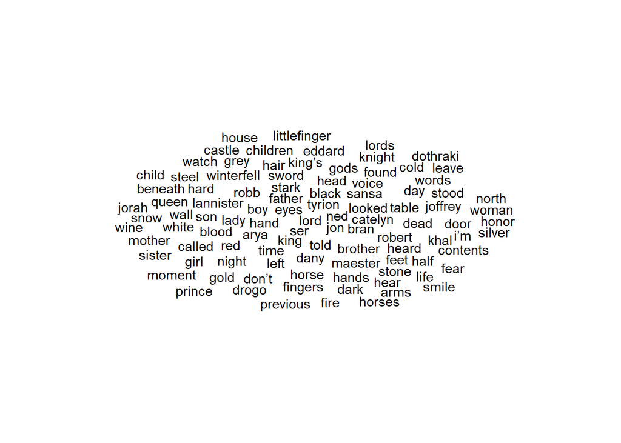

```r
got_cloud <- ggplot(data = got_top100, aes(label = word)) +
  geom_text_wordcloud() +
  theme_minimal()

got_cloud
```

The word cloud does contain some words pertaining to my initial hypothesis. Words such as ‘knight’ and ‘dead’. However, there are not quite as many as I had anticitipated.

This is quite a dull word cloud. In the following, a more visually appealing word cloud is produced, where the words used the most are quite big, which tells us more about word usage than the word cloud above.

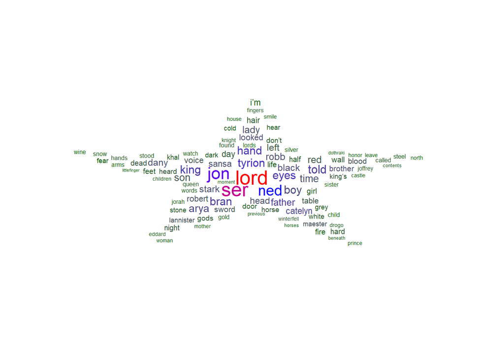

```r
ggplot(data = got_top100, aes(label = word, size = n)) +
  geom_text_wordcloud_area(aes(color = n), shape = "star") +
  scale_size_area(max_size = 12) +
  scale_color_gradientn(colors = c("darkgreen","blue","red")) +
  theme_minimal()
```

### Sentiment analysis

Let’s explore the sentiment lexicons. “bing” is included, other lexicons (“afinn”, “nrc”, “loughran”) you’ll be prompted to download.

Firstly, the sentiment lexicon “afinn” is explored. - “afinn”: Words ranked from -5 (very negative) to +5 (very positive)

```r
get_sentiments(lexicon = "afinn")
```

```
## # A tibble: 2,477 × 2
##    word       value
##    <chr>      <dbl>
##  1 abandon       -2
##  2 abandoned     -2
##  3 abandons      -2
##  4 abducted      -2
##  5 abduction     -2
##  6 abductions    -2
##  7 abhor         -3
##  8 abhorred      -3
##  9 abhorrent     -3
## 10 abhors        -3
## # ℹ 2,467 more rows
```

```r
# Looking at the positive words from the lexicon:
afinn_pos <- get_sentiments("afinn") %>%
  filter(value %in% c(3,4,5))

afinn_pos
```

```
## # A tibble: 222 × 2
##    word         value
##    <chr>        <dbl>
##  1 admire           3
##  2 admired          3
##  3 admires          3
##  4 admiring         3
##  5 adorable         3
##  6 adore            3
##  7 adored           3
##  8 adores           3
##  9 affection        3
## 10 affectionate     3
## # ℹ 212 more rows
```

Then, the sentiment lexicon “bing” is explored. - bing: binary, words are either “positive” or “negative”

```r
get_sentiments(lexicon = "bing")
```

```
## # A tibble: 6,786 × 2
##    word        sentiment
##    <chr>       <chr>
##  1 2-faces     negative
##  2 abnormal    negative
##  3 abolish     negative
##  4 abominable  negative
##  5 abominably  negative
##  6 abominate   negative
##  7 abomination negative
##  8 abort       negative
##  9 aborted     negative
## 10 aborts      negative
## # ℹ 6,776 more rows
```

Lastly, the sentiment lexicon nrc. - nrc: generates emotion features and applys them to each word

```r
get_sentiments(lexicon = "nrc")
```

```
## # A tibble: 13,872 × 2
##    word        sentiment
##    <chr>       <chr>
##  1 abacus      trust
##  2 abandon     fear
##  3 abandon     negative
##  4 abandon     sadness
##  5 abandoned   anger
##  6 abandoned   fear
##  7 abandoned   negative
##  8 abandoned   sadness
##  9 abandonment anger
## 10 abandonment fear
## # ℹ 13,862 more rows
```

Now, we are readu to do sentiment analysis on the Game of Thrones text data using afinn, and nrc.

### Sentiment analysis with afinn:

Firstly, one binds words in `got_stop` to `afinn` lexicon:

```r
got_afinn <- got_stop %>%
  inner_join(get_sentiments("afinn"))
got_afinn
```

```
## # A tibble: 13,058 × 2
##    word  value
##    <chr> <dbl>
##  1 fire     -2
##  2 dead     -3
##  3 dead     -3
##  4 smile     2
##  5 dead     -3
##  6 dead     -3
##  7 dead     -3
##  8 dead     -3
##  9 dead     -3
## 10 drag     -1
## # ℹ 13,048 more rows
```

Then, one finds some counts, by sentiment ranking:

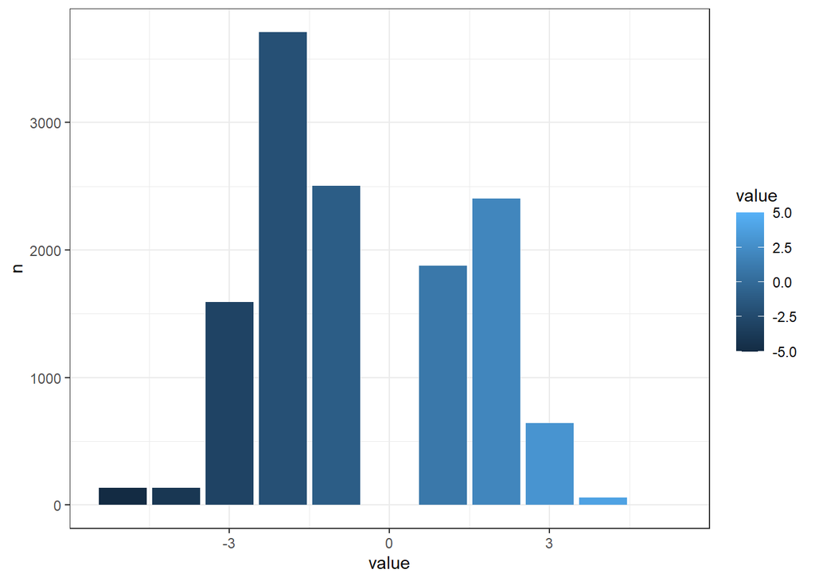

```r
got_afinn_hist <- got_afinn %>%
  count(value)

# Plotting the counted values:
ggplot(data = got_afinn_hist, aes(x = value, y = n)) +
  geom_col(aes(fill = value)) +
  theme_bw()
```

I did expect there to be more negative emotion than positive. However, I am surprised at how much positive emotion still is present within a novel I percieved to be quite dark.

Investigating some of the words more closely:

```r
# Looking more closely at the words assigned the 2 value
got_afinn2 <- got_afinn %>%
  filter(value == 2)
```

```r
# Checking the unique 2-score words:
unique(got_afinn2$word)
```

```
##   [1] "smile"           "fine"            "glory"           "hope"
##   [5] "smiled"          "care"            "strength"        "peaceful"
##   [9] "honor"           "carefully"       "slick"           "top"
##  [13] "gained"          "comfort"         "sweet"           "courage"
##  [17] "daring"          "elegant"         "justice"         "heroes"
##  [21] "fair"            "strong"          "brave"           "solid"
##  [25] "proud"           "mercy"           "rescue"          "swift"
##  [29] "smiling"         "true"            "noble"           "saved"
##  [33] "gift"            "treasures"       "favorite"        "clean"
##  [37] "rich"            "fearless"        "fortunate"       "likes"
##  [41] "earnest"         "generous"        "chances"         "smiles"
##  [45] "hug"             "kiss"            "approved"        "fond"
##  [49] "honored"         "consent"         "peace"           "powerful"
##  [53] "worthy"          "humor"           "entertaining"    "save"
##  [57] "sincerely"       "festive"         "careful"         "stronger"
```

[output cut: 36 more lines]

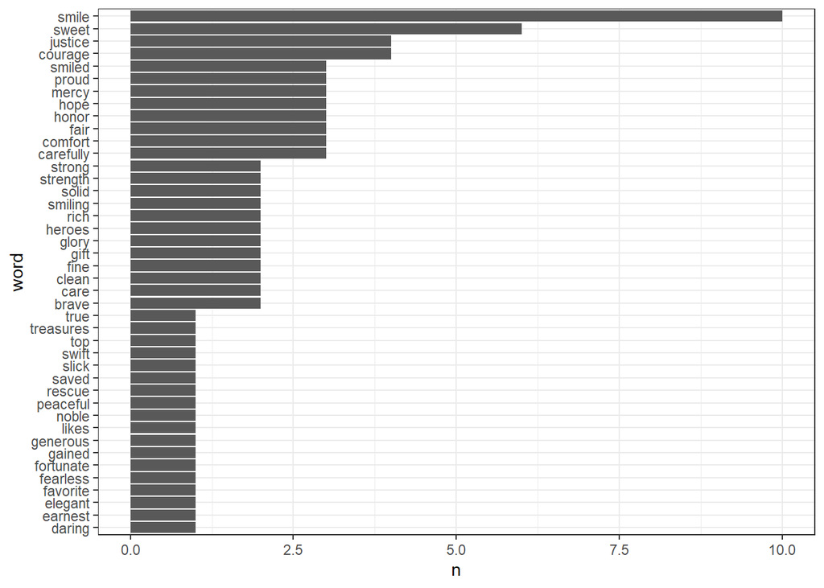

```r
# Counting & plotting them
got_afinn2_n <- got_afinn2 %>%
  count(word, sort = TRUE) %>%
  mutate(word = fct_reorder(factor(word), n))

# There are 201 unique words, that have the score 2. In order to create a tidy plot, I have created a vector with the first 100 unique 2-score words.

got_afinn2_head <- got_afinn2 %>%
  head(90)

# Counting and plotting the first 100 unique 2-score words:

got_afinn2_head_plot <- got_afinn2_head %>%
  count(word, sort = TRUE) %>%
  mutate(word = fct_reorder(factor(word), n))

# Creating the plot:

ggplot(data = got_afinn2_head_plot, aes(x = word, y = n)) +
  geom_col() +
  coord_flip() +
  theme_bw()
```

```r
# One word that can be argued is not primarily positive, is 'slick'. If a person is described slick, one is likely to have a sly and conniving nature. Thus, it can be negative. Another usage of the word is to describe the state of something one is feeling and sensing to be slick, such as a muddy road, or a person feeling slick with sweat. A muddy road or sweat is not overtly negative, but calling it positive also seem s strange. However, something can also be described as slick, if it is smooth, plain or glossy, such as the surface of a forest lake, it is not negative.
```

Looking at the book, slick is at one time used to describe an object, an arrowhead, which is mentioned as “The black glass was slick and shiny. [Bran] thought it beautiful”, on page 670 in the PDF. This is clearly positive, as the person observing the arrowhead believes it to be beautiful. However, quite a lot of instances of slick is used to describe someone or something being slick with blood. Such is the instance on page 127 “The dagger was still clutched tightly in his right hand, slick with blood”. This is quite negative, as one is holding a dagger, slick with another person’s blood.

This goes to show that a sentiment lexicon matching words will not distinguish between different uses of the words. This does not mean it is not useful, but one should rely solely on its output in one’s analysis.

However, it does tell us something about the words used. When summarizing and finding the median and the average value, one finds the average to be -0,541 and the median to be -1. Based on this, one can conclude that according to the afinn lexicon, Game of Thrones has more negative words than it has positive. As I expected, the book has more negtaive values then positive, However, not as negative as I believed it be before I started this sentiment analysis.

```r
got_summary <- got_afinn %>%
  summarize(
    mean_score = mean(value),
    median_score = median(value)
  )
got_summary
```

```
## # A tibble: 1 × 2
##   mean_score median_score
##        <dbl>        <dbl>
## 1     -0.542           -1
```

### NRC lexicon for sentiment analysis

Using the NRC lexicon to start “binning” text by the feelings they’re typically associated with. As has been done previously, one must use inner_join() to combine the GOT non-stopword text with the nrc lexicon:

```r
got_nrc <- got_stop %>%
  inner_join(get_sentiments("nrc"))
```

By doing this, certain words are excluded. We are able to check which words are excluded by using `anti_join()`:

```r
got_exclude <- got_stop %>%
  anti_join(get_sentiments("nrc"))
# View(got_exclude)

# Counting to find the most excludeded words:
got_exclude_n <- got_exclude %>%
  count(word, sort = TRUE)

head(got_exclude_n)
```

```
## # A tibble: 6 × 2
##   word       n
##   <chr>  <int>
## 1 ser     1023
## 2 jon      787
## 3 ned      743
## 4 tyrion   591
## 5 eyes     567
## 6 hand     567
```

Finding some counts:

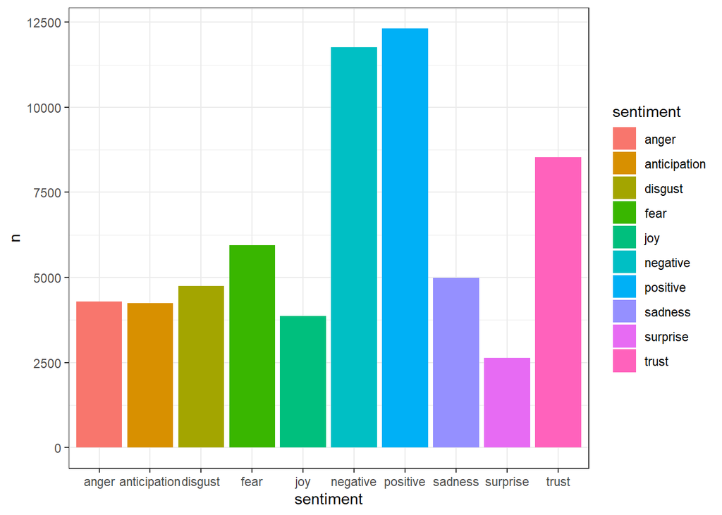

```r
got_nrc_n <- got_nrc %>%
  count(sentiment, sort = TRUE)

# And plotting them:

ggplot(data = got_nrc_n, aes(x = sentiment, y = n)) +
  geom_col(aes(fill = sentiment))+
  theme_bw()
```

Counting by sentiment *and* word, then facet:

```r
got_nrc_n5 <- got_nrc %>%
  count(word,sentiment, sort = TRUE) %>%
  group_by(sentiment) %>%
  top_n(4) %>%
  ungroup()
```

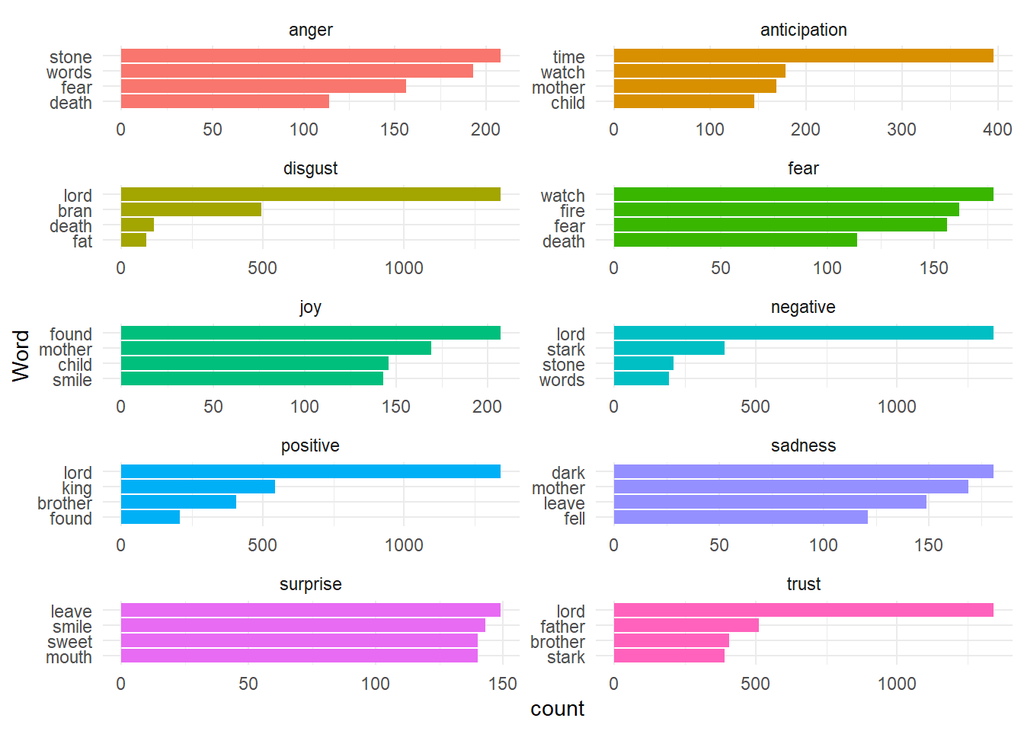

```r
got_nrc_gg <- ggplot(data = got_nrc_n5, aes(x = reorder(word,n), y = n, fill = sentiment)) +
  geom_col(show.legend = FALSE) +
  facet_wrap(~sentiment, ncol = 2, scales = "free") +
  coord_flip() +
  theme_minimal() +
  labs(x = "Word", y = "count")

# Showing it
got_nrc_gg
```

```r
# Saving it
ggsave(plot = got_nrc_gg,
       here("figures","got_nrc_sentiment.png"),
       height = 8,
       width = 5)
```

## Conclusion

Sentiment analysis is quite a useful tool to gain a quick and concise overview of the sentiments within a text. Doing this analysis, I learned that in the book Game of Thrones, negative emotions do not dominate nearly as much as I believed they would. In this particular case, it showcases that the book might not be as dark as people believe it to be. Perhaps this might inspire people, who previously believed the novel to be far too dark and negative for them, to give the book a proper chance. Using sentiment analysis on historical texts can also be useful. One might view a particular period in history as being predominately very dark and negative, or very positive and light. However, using sentiment analysis on texts of the time, one might be able to shine a light on new aspects of a certain historical period. Sentiment analysis makes this reexamination quick and easy. If one discovers nuances not previously known, then one can begin to do close-reading of the texts, to examine and highlight the new found aspects of the time.